# Alugueis visualização

Nabil A. Murtadha

29/10/2022

# Aluguéis em Brasília

Ter que morar de aluguel em Brasília sempre será um desafio. Não é novidade para ninguém que os preços são elevados e a qualidade dos apartamentos nem tanto, entretanto, muitos preferem a qualidade de vida que a Asa Sul e a Asa Norte conseguem oferece e o fato de ser “perto” de tudo. O aluguel no chega a comprometer até [30% da renda mensal dos moradores](https://noticias.r7.com/brasilia/df-record/videos/aluguel-compromete-30-do-orcamento-dos-moradores-do-centro-oeste-diz-pesquisa-28062022).

Eu mesmo já pensei o tão cômodo seria se morasse no Plano Piloto, ganharia bastante tempo útil, que hoje gasto apenas com deslocamento.

Mas o quão caro é morar no plano? Onde fica os apartamentos mais baratos? Os mais caros? Há diferença na média de preços entre Asa Sul e Asa Norte?

## Raspagem dos dados

Antes de tudo vamos coletar os dados!! O código abaixo foi utilizado para a raspagem de dados do site https://www.dfimoveis.com.br/.

```r
# Web Scraping ------------------------------------------------------------

link <- "https://www.dfimoveis.com.br/aluguel/df/brasilia/apartamento?pagina=1"
site <- read_html(link)

# titulos
site %>% html_nodes(".gtm-imovel") %>%
  html_text() %>%
  str_remove("\r\n") %>%
  str_remove("                                            ")

# links
site %>% html_nodes(".gtm-imovel") %>%
  html_attr("href")


# Funcoes -----------------------------------------------------------------

# Informacoes

info1 <- function(links){
  x <- paste0("https://www.dfimoveis.com.br",links)
  x <- read_html(x)
  apart1 <- x %>% html_nodes(".text-warning") %>%
    html_text() %>%
    unique() %>%
    paste(collapse = ";")
  return(apart1)
}

# informacoes 2

info2 <- function(links){
  x <- paste0("https://www.dfimoveis.com.br",links)
  x <- read_html(x)
  apart2 <- x %>% html_nodes(".text-muted") %>%
    html_text() %>%
    paste(collapse = ";")
  return(apart2)
}



# Data.frame --------------------------------------------------------------
base <- data.frame()
for (pag in c(1:96)) {
  link <-
    paste0("https://www.dfimoveis.com.br/aluguel/df/brasilia/apartamento?pagina=",
           pag)
  site <- read_html(link)
  titulo <- site %>% html_nodes(".gtm-imovel") %>%
    html_text() %>%
    str_remove("\r\n") %>%
    str_remove("                                            ")
  links <- site %>% html_nodes(".gtm-imovel") %>%
    html_attr("href")
  info1_char <- sapply(links, FUN = info1, USE.NAMES = F)
  info2_char <- sapply(links, FUN = info2, USE.NAMES = F)
  base <-
    rbind(base,
          data.frame(titulo, info1_char, info2_char,stringsAsFactors = F))
  print(paste("page:", pag))
}

#save(base, file = "alugueis_raw.Rdata")
```

## Manipulação

Após a raspagem o código abaixo manipula e limpa os dados para termos uma tabela formatada e pronta para ser feita as análises.

```r
# Carregando base ---------------------------------------------------------

load("alugueis_raw.Rdata")

# Tratando a base ---------------------------------------------------------

base_tratada <- base %>%
  separate(titulo,into = c("endereco","bairro","cidade"),",") %>%
  separate(info1_char, into = c("preco","area_util","valor_mq"),";") %>%
  mutate(quartos = str_match(info2_char,"[1-9] quarto"),
         suites = str_match(info2_char,"[1-9] suíte"),
         vaga = str_match(info2_char,"[1-9] vaga"),
         bairro = str_to_title(str_sub(bairro,start = 2))) %>%
  select(endereco, bairro, preco, area_util, valor_mq, quartos, suites, vaga) %>%
  as_tibble()



# Filtrando ---------------------------------------------------------------

base_tratada <- base_tratada %>% filter(bairro %in% c("Asa Sul","Asa Norte"))


# Ajustes -----------------------------------------------------------------

base_tratada <- base_tratada %>%
  mutate(quartos = as.numeric(str_match(quartos, "[1-9]")),
         suites = as.numeric(str_match(suites, "[1-9]")),
         vagas = as.numeric(str_match(vaga, "[1-9]")),
         preco = as.numeric(str_replace(preco,"[.]","")),
         area_util_mq = str_remove(area_util, "m²"),
         area_util_mq = as.numeric(str_replace(area_util_mq,"[,]",".")),
         altura_quadra = as.numeric(str_match(endereco, "[0-9]{3}")),
         bairro = factor(bairro)) %>%
  mutate(suites = as.numeric(str_replace_na(suites, 0)),
         vagas = as.numeric(str_replace_na(vagas, 0)),
         altura_quadra = case_when(altura_quadra %in% c(100:199)~"100",
                                  altura_quadra %in% c(200:299)~"200",
                                  altura_quadra %in% c(300:399)~"300",
                                  altura_quadra %in% c(400:499)~"400",
                                  altura_quadra %in% c(500:599)~"500",
                                  altura_quadra %in% c(600:699)~"600",
                                  altura_quadra %in% c(700:799)~"700",
                                  altura_quadra %in% c(800:899)~"800",
                                  altura_quadra %in% c(900:999)~"900")) %>%
  mutate(altura_quadra = str_replace_na(altura_quadra, "Outro")) %>%
  select(preco,bairro, altura_quadra, area_util_mq,quartos, suites, vagas) %>%
  filter(preco < 10000,
         area_util_mq < 600)

#save(base_tratada, file = "base_tratada.Rdata")
```

## Análises

```r
load("base_tratada.Rdata")

base_tratada <- base_tratada %>% filter(altura_quadra != "Outro") %>%
  mutate(altura_quadra = factor(altura_quadra)) %>%
  drop_na()

glimpse(base_tratada)
```

```
## Rows: 938
## Columns: 7
## $ preco         <dbl> 5600, 2850, 3250, 4000, 9900, 4500, 4600, 1100, 4100, 55~
## $ bairro        <fct> Asa Norte, Asa Sul, Asa Sul, Asa Norte, Asa Sul, Asa Nor~
## $ altura_quadra <fct> 200, 300, 400, 200, 100, 200, 300, 700, 500, 200, 100, 2~
## $ area_util_mq  <dbl> 105.00, 54.00, 92.00, 123.00, 232.00, 125.00, 123.00, 32~
## $ quartos       <dbl> 3, 2, 3, 3, 4, 3, 3, 1, 3, 4, 3, 2, 3, 1, 3, 3, 3, 3, 3,~
## $ suites        <dbl> 2, 0, 0, 1, 2, 1, 1, 1, 1, 1, 1, 0, 1, 1, 1, 1, 0, 0, 1,~
## $ vagas         <dbl> 1, 1, 0, 1, 1, 1, 1, 0, 1, 1, 1, 1, 0, 1, 1, 1, 0, 0, 1,~
```

### Gráficos

É sempre interessante plotar alguns gráficos, pois visualmente já é possível entender algumas características sobre os preços dos aluguéis em Brasília.

Por exemplo, o gráfico abaixo mostra a relação entre o preço do aluguel (eixo x) e a Área útil do apartamento. E mostra que quanto maior a área útil, maior o preço. Mostra também que a média de preços dos apartamentos da Asa Sul é levemente maior que os apartamentos da Asa Norte.

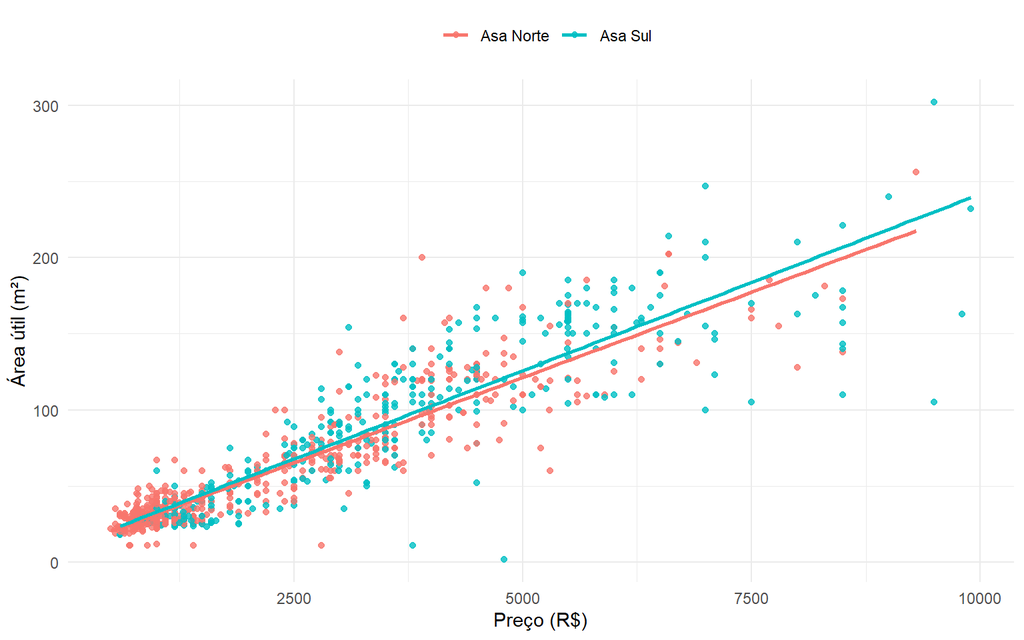

```r
base_tratada %>%
  ggplot(aes( x = preco, y = area_util_mq , color = bairro))+
  geom_point(alpha = .8)+
  geom_smooth(method = "lm",se = FALSE)+
  labs(x = "Preço (R$)", y = "Área útil (m²)")+
  theme_minimal()+theme(legend.position = "top",
                        legend.title = element_blank())
```

Outra relação muito interessante, é o preço do aluguel e a altura da quadra. O gráfico abaixo mostra muito bem onde estão os aluguéis mais baratos e os mais caros. De forma resumida, quanto mais longe do Eixão mais barato será o apartamento.

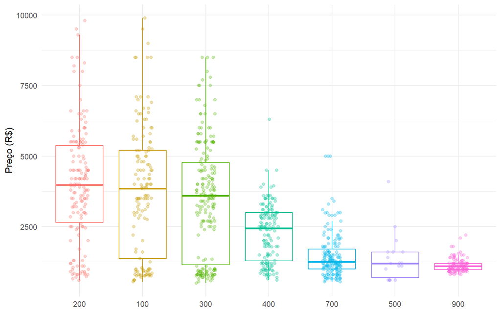

```r
base_tratada %>%
  filter(altura_quadra != "Outro") %>%
  mutate(altura_quadra = forcats::fct_reorder(altura_quadra,preco, median,.desc = TRUE)) %>%
  ggplot(aes(x = altura_quadra, y = preco, color = altura_quadra))+
  geom_boxplot(outlier.colour = NA)+
  geom_jitter(alpha = 0.3, width = 0.15)+
  labs(x = NULL, y = "Preço (R$)")+
  theme_minimal()+theme(legend.position = "NONE")
```

Porém, muito dessa relação está nas características de cada quadra. O gráfico abaixo mostra que as alturas da quadra com apartamentos mais caros são aqueles que possuem mais área útil por metro quadrado, portanto, a relação já mostrada no primeiro gráfico deste estudo

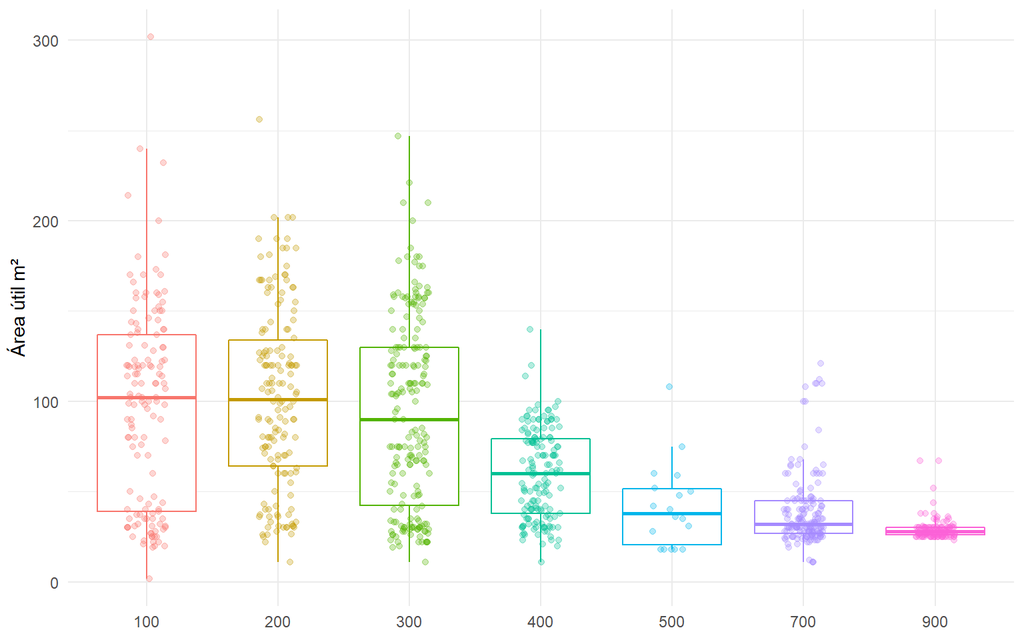

```r
base_tratada %>%
  filter(altura_quadra != "Outro") %>%
  mutate(altura_quadra = forcats::fct_reorder(altura_quadra,area_util_mq, median,.desc = TRUE)) %>%
  ggplot(aes(x = altura_quadra, y = area_util_mq, color = altura_quadra))+
  geom_boxplot(outlier.colour = NA)+
  geom_jitter(alpha = 0.3, width = 0.15)+
  labs(x = NULL, y = "Área útil m²")+
  theme_minimal()+theme(legend.position = "NONE")
```